# u11

## Shared Qs (u11)

#### Question

1. The [2D distance formula](https://en.wikipedia.org/wiki/Euclidean_distance#Two_dimensions) is an equivalent equation to the [Pythagorean equation](https://en.wikipedia.org/wiki/Pythagorean_theorem). When finding distance between two points on an $xy$-plane, it can be helpful to imagine a [right triangle](https://en.wikipedia.org/wiki/Right_triangle) with its legs horizontal and vertical, and its hypotenuse connecting the points. The length of the hypotenuse is the square root of the sum of the squares of the legs’ lengths. Each leg’s length is found by taking an absolute difference corresponding coordinates; for example $|x_2-x_1|$ is the length of the horizontal leg, and $|y_2-y_1|$ is the length of the vertical leg.

   A square field is 200 feet by 200 feet. The field is marked with a grid pattern, so the Southwest corner is at point $(0,0)$ and the Northeast corner is at point $(200,200)$. Near the middle, at position $(94, 97)$ is a beacon, marked as a large bright-red dot. On the field are 5 players; their positions are listed in the table below. Find how far each player is from the beacon.

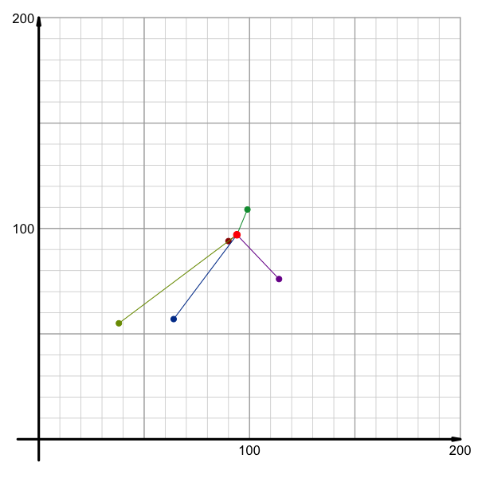

   I would recommend setting this up in Desmos using $d=\sqrt{(x_2-94)^2+(y_2-97)^2}$ and using sliders for $x_2$ and $y_2$.

   | Player | Position | Distance to beacon (ft) |
   | --- | --- | --- |
   | 1 | (90,94) |  |
   | 2 | (38,55) |  |
   | 3 | (99,109) |  |
   | 4 | (64,57) |  |
   | 5 | (114,76) |  |

#### Solution

#### Question

2. The [2D distance formula](https://en.wikipedia.org/wiki/Euclidean_distance#Two_dimensions) is an equivalent equation to the [Pythagorean equation](https://en.wikipedia.org/wiki/Pythagorean_theorem). When finding distance between two points on an $xy$-plane, it can be helpful to imagine a [right triangle](https://en.wikipedia.org/wiki/Right_triangle) with its legs horizontal and vertical, and its hypotenuse connecting the points. The length of the hypotenuse is the square root of the sum of the squares of the legs’ lengths. Each leg’s length is found by taking an absolute difference corresponding coordinates; for example $|x_2-x_1|$ is the length of the horizontal leg, and $|y_2-y_1|$ is the length of the vertical leg.

   A square field is 200 feet by 200 feet. The field is marked with a grid pattern, so the Southwest corner is at point $(0,0)$ and the Northeast corner is at point $(200,200)$. Near the middle, at position $(102, 105)$ is a beacon, marked as a large bright-red dot. On the field are 5 players; their positions are listed in the table below. Find how far each player is from the beacon.

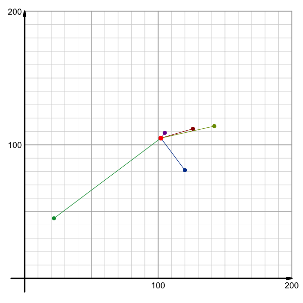

   I would recommend setting this up in Desmos using $d=\sqrt{(x_2-102)^2+(y_2-105)^2}$ and using sliders for $x_2$ and $y_2$.

   | Player | Position | Distance to beacon (ft) |
   | --- | --- | --- |
   | 1 | (126,112) |  |
   | 2 | (142,114) |  |
   | 3 | (22,45) |  |
   | 4 | (120,81) |  |
   | 5 | (105,109) |  |

#### Solution

#### Question

3. The [2D distance formula](https://en.wikipedia.org/wiki/Euclidean_distance#Two_dimensions) is an equivalent equation to the [Pythagorean equation](https://en.wikipedia.org/wiki/Pythagorean_theorem). When finding distance between two points on an $xy$-plane, it can be helpful to imagine a [right triangle](https://en.wikipedia.org/wiki/Right_triangle) with its legs horizontal and vertical, and its hypotenuse connecting the points. The length of the hypotenuse is the square root of the sum of the squares of the legs’ lengths. Each leg’s length is found by taking an absolute difference corresponding coordinates; for example $|x_2-x_1|$ is the length of the horizontal leg, and $|y_2-y_1|$ is the length of the vertical leg.

   A square field is 200 feet by 200 feet. The field is marked with a grid pattern, so the Southwest corner is at point $(0,0)$ and the Northeast corner is at point $(200,200)$. Near the middle, at position $(103, 98)$ is a beacon, marked as a large bright-red dot. On the field are 5 players; their positions are listed in the table below. Find how far each player is from the beacon.

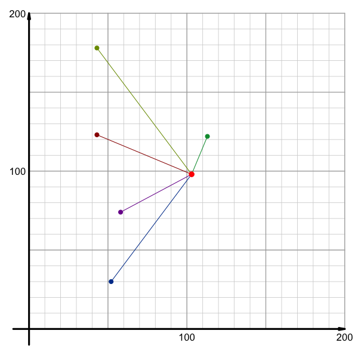

   I would recommend setting this up in Desmos using $d=\sqrt{(x_2-103)^2+(y_2-98)^2}$ and using sliders for $x_2$ and $y_2$.

   | Player | Position | Distance to beacon (ft) |
   | --- | --- | --- |
   | 1 | (43,123) |  |
   | 2 | (43,178) |  |
   | 3 | (113,122) |  |
   | 4 | (52,30) |  |
   | 5 | (58,74) |  |

#### Solution

#### Question

4. The [2D distance formula](https://en.wikipedia.org/wiki/Euclidean_distance#Two_dimensions) is an equivalent equation to the [Pythagorean equation](https://en.wikipedia.org/wiki/Pythagorean_theorem). When finding distance between two points on an $xy$-plane, it can be helpful to imagine a [right triangle](https://en.wikipedia.org/wiki/Right_triangle) with its legs horizontal and vertical, and its hypotenuse connecting the points. The length of the hypotenuse is the square root of the sum of the squares of the legs’ lengths. Each leg’s length is found by taking an absolute difference corresponding coordinates; for example $|x_2-x_1|$ is the length of the horizontal leg, and $|y_2-y_1|$ is the length of the vertical leg.

   A square field is 200 feet by 200 feet. The field is marked with a grid pattern, so the Southwest corner is at point $(0,0)$ and the Northeast corner is at point $(200,200)$. Near the middle, at position $(91, 101)$ is a beacon, marked as a large bright-red dot. On the field are 5 players; their positions are listed in the table below. Find how far each player is from the beacon.

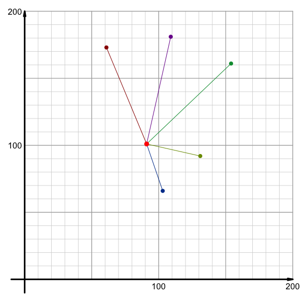

   I would recommend setting this up in Desmos using $d=\sqrt{(x_2-91)^2+(y_2-101)^2}$ and using sliders for $x_2$ and $y_2$.

   | Player | Position | Distance to beacon (ft) |
   | --- | --- | --- |
   | 1 | (61,173) |  |
   | 2 | (131,92) |  |
   | 3 | (154,161) |  |
   | 4 | (103,66) |  |
   | 5 | (109,181) |  |

#### Solution

#### Question

5. The [2D distance formula](https://en.wikipedia.org/wiki/Euclidean_distance#Two_dimensions) is an equivalent equation to the [Pythagorean equation](https://en.wikipedia.org/wiki/Pythagorean_theorem). When finding distance between two points on an $xy$-plane, it can be helpful to imagine a [right triangle](https://en.wikipedia.org/wiki/Right_triangle) with its legs horizontal and vertical, and its hypotenuse connecting the points. The length of the hypotenuse is the square root of the sum of the squares of the legs’ lengths. Each leg’s length is found by taking an absolute difference corresponding coordinates; for example $|x_2-x_1|$ is the length of the horizontal leg, and $|y_2-y_1|$ is the length of the vertical leg.

   A square field is 200 feet by 200 feet. The field is marked with a grid pattern, so the Southwest corner is at point $(0,0)$ and the Northeast corner is at point $(200,200)$. Near the middle, at position $(104, 107)$ is a beacon, marked as a large bright-red dot. On the field are 5 players; their positions are listed in the table below. Find how far each player is from the beacon.

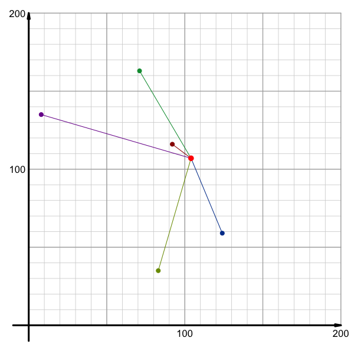

   I would recommend setting this up in Desmos using $d=\sqrt{(x_2-104)^2+(y_2-107)^2}$ and using sliders for $x_2$ and $y_2$.

   | Player | Position | Distance to beacon (ft) |
   | --- | --- | --- |
   | 1 | (92,116) |  |
   | 2 | (83,35) |  |
   | 3 | (71,163) |  |
   | 4 | (124,59) |  |
   | 5 | (8,135) |  |

#### Solution

#### Question

6. The [2D distance formula](https://en.wikipedia.org/wiki/Euclidean_distance#Two_dimensions) is an equivalent equation to the [Pythagorean equation](https://en.wikipedia.org/wiki/Pythagorean_theorem). When finding distance between two points on an $xy$-plane, it can be helpful to imagine a [right triangle](https://en.wikipedia.org/wiki/Right_triangle) with its legs horizontal and vertical, and its hypotenuse connecting the points. The length of the hypotenuse is the square root of the sum of the squares of the legs’ lengths. Each leg’s length is found by taking an absolute difference corresponding coordinates; for example $|x_2-x_1|$ is the length of the horizontal leg, and $|y_2-y_1|$ is the length of the vertical leg.

   A square field is 200 feet by 200 feet. The field is marked with a grid pattern, so the Southwest corner is at point $(0,0)$ and the Northeast corner is at point $(200,200)$. Near the middle, at position $(92, 109)$ is a beacon, marked as a large bright-red dot. On the field are 5 players; their positions are listed in the table below. Find how far each player is from the beacon.

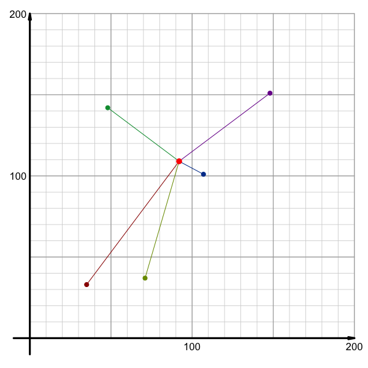

   I would recommend setting this up in Desmos using $d=\sqrt{(x_2-92)^2+(y_2-109)^2}$ and using sliders for $x_2$ and $y_2$.

   | Player | Position | Distance to beacon (ft) |
   | --- | --- | --- |
   | 1 | (35,33) |  |
   | 2 | (71,37) |  |
   | 3 | (48,142) |  |
   | 4 | (107,101) |  |
   | 5 | (148,151) |  |

#### Solution

#### Question

7. The [2D distance formula](https://en.wikipedia.org/wiki/Euclidean_distance#Two_dimensions) is an equivalent equation to the [Pythagorean equation](https://en.wikipedia.org/wiki/Pythagorean_theorem). When finding distance between two points on an $xy$-plane, it can be helpful to imagine a [right triangle](https://en.wikipedia.org/wiki/Right_triangle) with its legs horizontal and vertical, and its hypotenuse connecting the points. The length of the hypotenuse is the square root of the sum of the squares of the legs’ lengths. Each leg’s length is found by taking an absolute difference corresponding coordinates; for example $|x_2-x_1|$ is the length of the horizontal leg, and $|y_2-y_1|$ is the length of the vertical leg.

   A square field is 200 feet by 200 feet. The field is marked with a grid pattern, so the Southwest corner is at point $(0,0)$ and the Northeast corner is at point $(200,200)$. Near the middle, at position $(107, 95)$ is a beacon, marked as a large bright-red dot. On the field are 5 players; their positions are listed in the table below. Find how far each player is from the beacon.

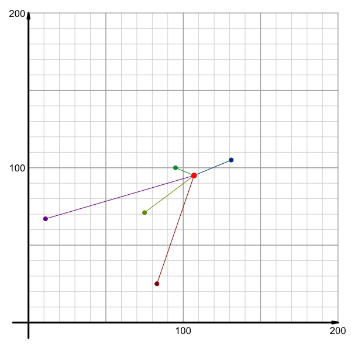

   I would recommend setting this up in Desmos using $d=\sqrt{(x_2-107)^2+(y_2-95)^2}$ and using sliders for $x_2$ and $y_2$.

   | Player | Position | Distance to beacon (ft) |
   | --- | --- | --- |
   | 1 | (83,25) |  |
   | 2 | (75,71) |  |
   | 3 | (95,100) |  |
   | 4 | (131,105) |  |
   | 5 | (11,67) |  |

#### Solution

#### Question

8. The [2D distance formula](https://en.wikipedia.org/wiki/Euclidean_distance#Two_dimensions) is an equivalent equation to the [Pythagorean equation](https://en.wikipedia.org/wiki/Pythagorean_theorem). When finding distance between two points on an $xy$-plane, it can be helpful to imagine a [right triangle](https://en.wikipedia.org/wiki/Right_triangle) with its legs horizontal and vertical, and its hypotenuse connecting the points. The length of the hypotenuse is the square root of the sum of the squares of the legs’ lengths. Each leg’s length is found by taking an absolute difference corresponding coordinates; for example $|x_2-x_1|$ is the length of the horizontal leg, and $|y_2-y_1|$ is the length of the vertical leg.

   A square field is 200 feet by 200 feet. The field is marked with a grid pattern, so the Southwest corner is at point $(0,0)$ and the Northeast corner is at point $(200,200)$. Near the middle, at position $(99, 109)$ is a beacon, marked as a large bright-red dot. On the field are 5 players; their positions are listed in the table below. Find how far each player is from the beacon.

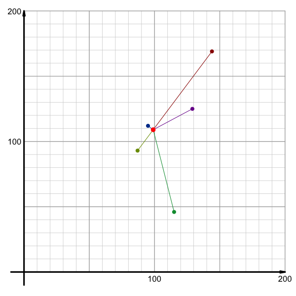

   I would recommend setting this up in Desmos using $d=\sqrt{(x_2-99)^2+(y_2-109)^2}$ and using sliders for $x_2$ and $y_2$.

   | Player | Position | Distance to beacon (ft) |
   | --- | --- | --- |
   | 1 | (144,169) |  |
   | 2 | (87,93) |  |
   | 3 | (115,46) |  |
   | 4 | (95,112) |  |
   | 5 | (129,125) |  |

#### Solution

#### Question

9. The [2D distance formula](https://en.wikipedia.org/wiki/Euclidean_distance#Two_dimensions) is an equivalent equation to the [Pythagorean equation](https://en.wikipedia.org/wiki/Pythagorean_theorem). When finding distance between two points on an $xy$-plane, it can be helpful to imagine a [right triangle](https://en.wikipedia.org/wiki/Right_triangle) with its legs horizontal and vertical, and its hypotenuse connecting the points. The length of the hypotenuse is the square root of the sum of the squares of the legs’ lengths. Each leg’s length is found by taking an absolute difference corresponding coordinates; for example $|x_2-x_1|$ is the length of the horizontal leg, and $|y_2-y_1|$ is the length of the vertical leg.

   A square field is 200 feet by 200 feet. The field is marked with a grid pattern, so the Southwest corner is at point $(0,0)$ and the Northeast corner is at point $(200,200)$. Near the middle, at position $(95, 102)$ is a beacon, marked as a large bright-red dot. On the field are 5 players; their positions are listed in the table below. Find how far each player is from the beacon.

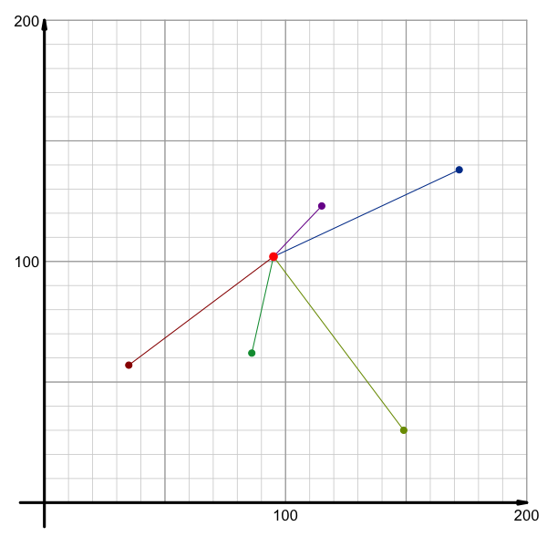

   I would recommend setting this up in Desmos using $d=\sqrt{(x_2-95)^2+(y_2-102)^2}$ and using sliders for $x_2$ and $y_2$.

   | Player | Position | Distance to beacon (ft) |
   | --- | --- | --- |
   | 1 | (35,57) |  |
   | 2 | (149,30) |  |
   | 3 | (86,62) |  |
   | 4 | (172,138) |  |
   | 5 | (115,123) |  |

#### Solution

#### Question

10. The [2D distance formula](https://en.wikipedia.org/wiki/Euclidean_distance#Two_dimensions) is an equivalent equation to the [Pythagorean equation](https://en.wikipedia.org/wiki/Pythagorean_theorem). When finding distance between two points on an $xy$-plane, it can be helpful to imagine a [right triangle](https://en.wikipedia.org/wiki/Right_triangle) with its legs horizontal and vertical, and its hypotenuse connecting the points. The length of the hypotenuse is the square root of the sum of the squares of the legs’ lengths. Each leg’s length is found by taking an absolute difference corresponding coordinates; for example $|x_2-x_1|$ is the length of the horizontal leg, and $|y_2-y_1|$ is the length of the vertical leg.

    A square field is 200 feet by 200 feet. The field is marked with a grid pattern, so the Southwest corner is at point $(0,0)$ and the Northeast corner is at point $(200,200)$. Near the middle, at position $(105, 95)$ is a beacon, marked as a large bright-red dot. On the field are 5 players; their positions are listed in the table below. Find how far each player is from the beacon.

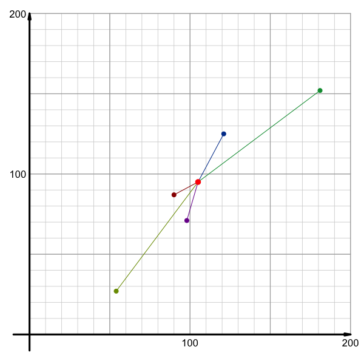

    I would recommend setting this up in Desmos using $d=\sqrt{(x_2-105)^2+(y_2-95)^2}$ and using sliders for $x_2$ and $y_2$.

    | Player | Position | Distance to beacon (ft) |
    | --- | --- | --- |
    | 1 | (90,87) |  |
    | 2 | (54,27) |  |
    | 3 | (181,152) |  |
    | 4 | (121,125) |  |
    | 5 | (98,71) |  |

#### Solution

#### Question

11. Using [Desmos](https://www.desmos.com/calculator), determine which of the given points are within a distance of 11 units from point (3, 5).
    1. Graph the inequality $(x-3)^2+(y-5)^2~\le~11^2$ as the first item in Desmos.
    2. Enter each point as a [Cartesian coordinate pair](https://en.wikipedia.org/wiki/Abscissa_and_ordinate). Actually, you should be able to copy/paste all the points as a single item (using commas to separate the points):
    - (12,11), (11,14), (7,16), (-1,14), (-5,12), (-8,2), (-7,1), (-2,-5), (8,-5), (15,2)
    3. Click “Label” to label the points.
    4. Determine which points are in the shaded area. If a point is exactly on the boundary, count that point as within the distance. You might need to zoom in on points to be sure.
    1. (12,11)
    2. (11,14)
    3. (7,16)
    4. (-1,14)
    5. (-5,12)
    6. (-8,2)
    7. (-7,1)
    8. (-2,-5)
    9. (8,-5)
    10. (15,2)

#### Solution

#### Question

12. Using [Desmos](https://www.desmos.com/calculator), determine which of the given points are within a distance of 11 units from point (6, 4).
    1. Graph the inequality $(x-6)^2+(y-4)^2~\le~11^2$ as the first item in Desmos.
    2. Enter each point as a [Cartesian coordinate pair](https://en.wikipedia.org/wiki/Abscissa_and_ordinate). Actually, you should be able to copy/paste all the points as a single item (using commas to separate the points):
    - (17,9), (9,13), (4,15), (-1,11), (-3,10), (-3,0), (-3,-5), (5,-7), (12,-6), (18,2)
    3. Click “Label” to label the points.
    4. Determine which points are in the shaded area. If a point is exactly on the boundary, count that point as within the distance. You might need to zoom in on points to be sure.
    1. (17,9)
    2. (9,13)
    3. (4,15)
    4. (-1,11)
    5. (-3,10)
    6. (-3,0)
    7. (-3,-5)
    8. (5,-7)
    9. (12,-6)
    10. (18,2)

#### Solution

#### Question

13. Using [Desmos](https://www.desmos.com/calculator), determine which of the given points are within a distance of 8 units from point (-6, 1).
    1. Graph the inequality $(x+6)^2+(y-1)^2~\le~8^2$ as the first item in Desmos.
    2. Enter each point as a [Cartesian coordinate pair](https://en.wikipedia.org/wiki/Abscissa_and_ordinate). Actually, you should be able to copy/paste all the points as a single item (using commas to separate the points):
    - (3,3), (-2,7), (-6,8), (-9,7), (-12,4), (-14,-2), (-9,-6), (-3,-8), (2,-2), (2,-1)
    3. Click “Label” to label the points.
    4. Determine which points are in the shaded area. If a point is exactly on the boundary, count that point as within the distance. You might need to zoom in on points to be sure.
    1. (3,3)
    2. (-2,7)
    3. (-6,8)
    4. (-9,7)
    5. (-12,4)
    6. (-14,-2)
    7. (-9,-6)
    8. (-3,-8)
    9. (2,-2)
    10. (2,-1)

#### Solution

#### Question

14. Using [Desmos](https://www.desmos.com/calculator), determine which of the given points are within a distance of 15 units from point (5, -1).
    1. Graph the inequality $(x-5)^2+(y+1)^2~\le~15^2$ as the first item in Desmos.
    2. Enter each point as a [Cartesian coordinate pair](https://en.wikipedia.org/wiki/Abscissa_and_ordinate). Actually, you should be able to copy/paste all the points as a single item (using commas to separate the points):
    - (18,9), (16,9), (4,14), (-6,10), (-10,-2), (-4,-13), (3,-17), (9,-14), (20,-7), (20,-3)
    3. Click “Label” to label the points.
    4. Determine which points are in the shaded area. If a point is exactly on the boundary, count that point as within the distance. You might need to zoom in on points to be sure.
    1. (18,9)
    2. (16,9)
    3. (4,14)
    4. (-6,10)
    5. (-10,-2)
    6. (-4,-13)
    7. (3,-17)
    8. (9,-14)
    9. (20,-7)
    10. (20,-3)

#### Solution

#### Question

15. Using [Desmos](https://www.desmos.com/calculator), determine which of the given points are within a distance of 8 units from point (-2, -3).
    1. Graph the inequality $(x+2)^2+(y+3)^2~\le~8^2$ as the first item in Desmos.
    2. Enter each point as a [Cartesian coordinate pair](https://en.wikipedia.org/wiki/Abscissa_and_ordinate). Actually, you should be able to copy/paste all the points as a single item (using commas to separate the points):
    - (6,-3), (4,5), (1,6), (-6,4), (-10,2), (-11,-4), (-9,-5), (-6,-9), (2,-10), (5,-8)
    3. Click “Label” to label the points.
    4. Determine which points are in the shaded area. If a point is exactly on the boundary, count that point as within the distance. You might need to zoom in on points to be sure.
    1. (6,-3)
    2. (4,5)
    3. (1,6)
    4. (-6,4)
    5. (-10,2)
    6. (-11,-4)
    7. (-9,-5)
    8. (-6,-9)
    9. (2,-10)
    10. (5,-8)

#### Solution

#### Question

16. Using [Desmos](https://www.desmos.com/calculator), determine which of the given points are within a distance of 15 units from point (6, -8).
    1. Graph the inequality $(x-6)^2+(y+8)^2~\le~15^2$ as the first item in Desmos.
    2. Enter each point as a [Cartesian coordinate pair](https://en.wikipedia.org/wiki/Abscissa_and_ordinate). Actually, you should be able to copy/paste all the points as a single item (using commas to separate the points):
    - (18,-1), (15,5), (3,5), (-8,1), (-9,-8), (-9,-9), (-2,-22), (9,-22), (21,-14), (20,-9)
    3. Click “Label” to label the points.
    4. Determine which points are in the shaded area. If a point is exactly on the boundary, count that point as within the distance. You might need to zoom in on points to be sure.
    1. (18,-1)
    2. (15,5)
    3. (3,5)
    4. (-8,1)
    5. (-9,-8)
    6. (-9,-9)
    7. (-2,-22)
    8. (9,-22)
    9. (21,-14)
    10. (20,-9)

#### Solution

#### Question

17. Using [Desmos](https://www.desmos.com/calculator), determine which of the given points are within a distance of 10 units from point (3, 2).
    1. Graph the inequality $(x-3)^2+(y-2)^2~\le~10^2$ as the first item in Desmos.
    2. Enter each point as a [Cartesian coordinate pair](https://en.wikipedia.org/wiki/Abscissa_and_ordinate). Actually, you should be able to copy/paste all the points as a single item (using commas to separate the points):
    - (12,6), (2,12), (-2,11), (-6,8), (-6,1), (-2,-6), (0,-7), (5,-8), (4,-7), (11,-3)
    3. Click “Label” to label the points.
    4. Determine which points are in the shaded area. If a point is exactly on the boundary, count that point as within the distance. You might need to zoom in on points to be sure.
    1. (12,6)
    2. (2,12)
    3. (-2,11)
    4. (-6,8)
    5. (-6,1)
    6. (-2,-6)
    7. (0,-7)
    8. (5,-8)
    9. (4,-7)
    10. (11,-3)

#### Solution

#### Question

18. Using [Desmos](https://www.desmos.com/calculator), determine which of the given points are within a distance of 15 units from point (7, 4).
    1. Graph the inequality $(x-7)^2+(y-4)^2~\le~15^2$ as the first item in Desmos.
    2. Enter each point as a [Cartesian coordinate pair](https://en.wikipedia.org/wiki/Abscissa_and_ordinate). Actually, you should be able to copy/paste all the points as a single item (using commas to separate the points):
    - (21,7), (17,15), (2,18), (-8,8), (-7,-4), (-1,-8), (1,-8), (4,-9), (13,-11), (20,-4)
    3. Click “Label” to label the points.
    4. Determine which points are in the shaded area. If a point is exactly on the boundary, count that point as within the distance. You might need to zoom in on points to be sure.
    1. (21,7)
    2. (17,15)
    3. (2,18)
    4. (-8,8)
    5. (-7,-4)
    6. (-1,-8)
    7. (1,-8)
    8. (4,-9)
    9. (13,-11)
    10. (20,-4)

#### Solution

#### Question

19. Using [Desmos](https://www.desmos.com/calculator), determine which of the given points are within a distance of 15 units from point (8, -4).
    1. Graph the inequality $(x-8)^2+(y+4)^2~\le~15^2$ as the first item in Desmos.
    2. Enter each point as a [Cartesian coordinate pair](https://en.wikipedia.org/wiki/Abscissa_and_ordinate). Actually, you should be able to copy/paste all the points as a single item (using commas to separate the points):
    - (24,-3), (16,9), (2,10), (-4,4), (-7,-1), (-4,-12), (8,-19), (9,-18), (17,-14), (22,-5)
    3. Click “Label” to label the points.
    4. Determine which points are in the shaded area. If a point is exactly on the boundary, count that point as within the distance. You might need to zoom in on points to be sure.
    1. (24,-3)
    2. (16,9)
    3. (2,10)
    4. (-4,4)
    5. (-7,-1)
    6. (-4,-12)
    7. (8,-19)
    8. (9,-18)
    9. (17,-14)
    10. (22,-5)

#### Solution

#### Question

20. Using [Desmos](https://www.desmos.com/calculator), determine which of the given points are within a distance of 13 units from point (-2, -7).
    1. Graph the inequality $(x+2)^2+(y+7)^2~\le~13^2$ as the first item in Desmos.
    2. Enter each point as a [Cartesian coordinate pair](https://en.wikipedia.org/wiki/Abscissa_and_ordinate). Actually, you should be able to copy/paste all the points as a single item (using commas to separate the points):
    - (12,-7), (11,-5), (2,6), (-8,4), (-13,-2), (-15,-3), (-15,-8), (-10,-17), (0,-21), (6,-15)
    3. Click “Label” to label the points.
    4. Determine which points are in the shaded area. If a point is exactly on the boundary, count that point as within the distance. You might need to zoom in on points to be sure.
    1. (12,-7)
    2. (11,-5)
    3. (2,6)
    4. (-8,4)
    5. (-13,-2)
    6. (-15,-3)
    7. (-15,-8)
    8. (-10,-17)
    9. (0,-21)
    10. (6,-15)

#### Solution

#### Question

21. A circle has a center and a radius. The distance from the center to any point on the edge equals the radius.

    In Desmos, we can graph a circle using an equation that looks like [the Pythagorean equation](https://en.wikipedia.org/wiki/Pythagorean_theorem) and the [2D distance formula](https://en.wikipedia.org/wiki/Euclidean_distance#Two_dimensions). If the center is at $(h,k)$ and the radius equals $r$, the following equation graphs the desired circle in an $xy$-plane.

    $$(x-h)^2+(y-k)^2~=~r^2$$

    A large square lake is 200 miles across. The positions of 3 lighthouses are known, as well as the distance from each lighthouse to a boat.

    | lighthouse | position (miles, miles) | distance to boat (miles) |
    | --- | --- | --- |
    | 1 | $(98,117)$ | $25$ |
    | 2 | $(77,45)$ | $50$ |
    | 3 | $(115,111)$ | $30$ |

    Use [trilateration](https://en.wikipedia.org/wiki/Trilateration) to find the position of the boat:

    (, )

#### Solution

#### Question

22. A circle has a center and a radius. The distance from the center to any point on the edge equals the radius.

    In Desmos, we can graph a circle using an equation that looks like [the Pythagorean equation](https://en.wikipedia.org/wiki/Pythagorean_theorem) and the [2D distance formula](https://en.wikipedia.org/wiki/Euclidean_distance#Two_dimensions). If the center is at $(h,k)$ and the radius equals $r$, the following equation graphs the desired circle in an $xy$-plane.

    $$(x-h)^2+(y-k)^2~=~r^2$$

    A large square lake is 200 miles across. The positions of 3 lighthouses are known, as well as the distance from each lighthouse to a boat.

    | lighthouse | position (miles, miles) | distance to boat (miles) |
    | --- | --- | --- |
    | 1 | $(142,83)$ | $37$ |
    | 2 | $(43,47)$ | $80$ |
    | 3 | $(67,170)$ | $85$ |

    Use [trilateration](https://en.wikipedia.org/wiki/Trilateration) to find the position of the boat:

    (, )

#### Solution

#### Question

23. A circle has a center and a radius. The distance from the center to any point on the edge equals the radius.

    In Desmos, we can graph a circle using an equation that looks like [the Pythagorean equation](https://en.wikipedia.org/wiki/Pythagorean_theorem) and the [2D distance formula](https://en.wikipedia.org/wiki/Euclidean_distance#Two_dimensions). If the center is at $(h,k)$ and the radius equals $r$, the following equation graphs the desired circle in an $xy$-plane.

    $$(x-h)^2+(y-k)^2~=~r^2$$

    A large square lake is 200 miles across. The positions of 3 lighthouses are known, as well as the distance from each lighthouse to a boat.

    | lighthouse | position (miles, miles) | distance to boat (miles) |
    | --- | --- | --- |
    | 1 | $(120,67)$ | $40$ |
    | 2 | $(168,45)$ | $90$ |
    | 3 | $(83,183)$ | $85$ |

    Use [trilateration](https://en.wikipedia.org/wiki/Trilateration) to find the position of the boat:

    (, )

#### Solution

#### Question

24. A circle has a center and a radius. The distance from the center to any point on the edge equals the radius.

    In Desmos, we can graph a circle using an equation that looks like [the Pythagorean equation](https://en.wikipedia.org/wiki/Pythagorean_theorem) and the [2D distance formula](https://en.wikipedia.org/wiki/Euclidean_distance#Two_dimensions). If the center is at $(h,k)$ and the radius equals $r$, the following equation graphs the desired circle in an $xy$-plane.

    $$(x-h)^2+(y-k)^2~=~r^2$$

    A large square lake is 200 miles across. The positions of 3 lighthouses are known, as well as the distance from each lighthouse to a boat.

    | lighthouse | position (miles, miles) | distance to boat (miles) |
    | --- | --- | --- |
    | 1 | $(88,85)$ | $25$ |
    | 2 | $(32,157)$ | $95$ |
    | 3 | $(192,113)$ | $85$ |

    Use [trilateration](https://en.wikipedia.org/wiki/Trilateration) to find the position of the boat:

    (, )

#### Solution

#### Question

25. A circle has a center and a radius. The distance from the center to any point on the edge equals the radius.

    In Desmos, we can graph a circle using an equation that looks like [the Pythagorean equation](https://en.wikipedia.org/wiki/Pythagorean_theorem) and the [2D distance formula](https://en.wikipedia.org/wiki/Euclidean_distance#Two_dimensions). If the center is at $(h,k)$ and the radius equals $r$, the following equation graphs the desired circle in an $xy$-plane.

    $$(x-h)^2+(y-k)^2~=~r^2$$

    A large square lake is 200 miles across. The positions of 3 lighthouses are known, as well as the distance from each lighthouse to a boat.

    | lighthouse | position (miles, miles) | distance to boat (miles) |
    | --- | --- | --- |
    | 1 | $(85,83)$ | $15$ |
    | 2 | $(40,23)$ | $90$ |
    | 3 | $(70,102)$ | $25$ |

    Use [trilateration](https://en.wikipedia.org/wiki/Trilateration) to find the position of the boat:

    (, )

#### Solution

#### Question

26. A circle has a center and a radius. The distance from the center to any point on the edge equals the radius.

    In Desmos, we can graph a circle using an equation that looks like [the Pythagorean equation](https://en.wikipedia.org/wiki/Pythagorean_theorem) and the [2D distance formula](https://en.wikipedia.org/wiki/Euclidean_distance#Two_dimensions). If the center is at $(h,k)$ and the radius equals $r$, the following equation graphs the desired circle in an $xy$-plane.

    $$(x-h)^2+(y-k)^2~=~r^2$$

    A large square lake is 200 miles across. The positions of 3 lighthouses are known, as well as the distance from each lighthouse to a boat.

    | lighthouse | position (miles, miles) | distance to boat (miles) |
    | --- | --- | --- |
    | 1 | $(31,37)$ | $97$ |
    | 2 | $(94,114)$ | $15$ |
    | 3 | $(173,78)$ | $74$ |

    Use [trilateration](https://en.wikipedia.org/wiki/Trilateration) to find the position of the boat:

    (, )

#### Solution

#### Question

27. A circle has a center and a radius. The distance from the center to any point on the edge equals the radius.

    In Desmos, we can graph a circle using an equation that looks like [the Pythagorean equation](https://en.wikipedia.org/wiki/Pythagorean_theorem) and the [2D distance formula](https://en.wikipedia.org/wiki/Euclidean_distance#Two_dimensions). If the center is at $(h,k)$ and the radius equals $r$, the following equation graphs the desired circle in an $xy$-plane.

    $$(x-h)^2+(y-k)^2~=~r^2$$

    A large square lake is 200 miles across. The positions of 3 lighthouses are known, as well as the distance from each lighthouse to a boat.

    | lighthouse | position (miles, miles) | distance to boat (miles) |
    | --- | --- | --- |
    | 1 | $(124,51)$ | $52$ |
    | 2 | $(28,42)$ | $95$ |
    | 3 | $(88,129)$ | $34$ |

    Use [trilateration](https://en.wikipedia.org/wiki/Trilateration) to find the position of the boat:

    (, )

#### Solution

#### Question

28. A circle has a center and a radius. The distance from the center to any point on the edge equals the radius.

    In Desmos, we can graph a circle using an equation that looks like [the Pythagorean equation](https://en.wikipedia.org/wiki/Pythagorean_theorem) and the [2D distance formula](https://en.wikipedia.org/wiki/Euclidean_distance#Two_dimensions). If the center is at $(h,k)$ and the radius equals $r$, the following equation graphs the desired circle in an $xy$-plane.

    $$(x-h)^2+(y-k)^2~=~r^2$$

    A large square lake is 200 miles across. The positions of 3 lighthouses are known, as well as the distance from each lighthouse to a boat.

    | lighthouse | position (miles, miles) | distance to boat (miles) |
    | --- | --- | --- |
    | 1 | $(163,149)$ | $73$ |
    | 2 | $(153,125)$ | $51$ |
    | 3 | $(112,98)$ | $5$ |

    Use [trilateration](https://en.wikipedia.org/wiki/Trilateration) to find the position of the boat:

    (, )

#### Solution

#### Question

29. A circle has a center and a radius. The distance from the center to any point on the edge equals the radius.

    In Desmos, we can graph a circle using an equation that looks like [the Pythagorean equation](https://en.wikipedia.org/wiki/Pythagorean_theorem) and the [2D distance formula](https://en.wikipedia.org/wiki/Euclidean_distance#Two_dimensions). If the center is at $(h,k)$ and the radius equals $r$, the following equation graphs the desired circle in an $xy$-plane.

    $$(x-h)^2+(y-k)^2~=~r^2$$

    A large square lake is 200 miles across. The positions of 3 lighthouses are known, as well as the distance from each lighthouse to a boat.

    | lighthouse | position (miles, miles) | distance to boat (miles) |
    | --- | --- | --- |
    | 1 | $(7,65)$ | $100$ |
    | 2 | $(87,63)$ | $34$ |
    | 3 | $(52,161)$ | $85$ |

    Use [trilateration](https://en.wikipedia.org/wiki/Trilateration) to find the position of the boat:

    (, )

#### Solution

#### Question

30. A circle has a center and a radius. The distance from the center to any point on the edge equals the radius.

    In Desmos, we can graph a circle using an equation that looks like [the Pythagorean equation](https://en.wikipedia.org/wiki/Pythagorean_theorem) and the [2D distance formula](https://en.wikipedia.org/wiki/Euclidean_distance#Two_dimensions). If the center is at $(h,k)$ and the radius equals $r$, the following equation graphs the desired circle in an $xy$-plane.

    $$(x-h)^2+(y-k)^2~=~r^2$$

    A large square lake is 200 miles across. The positions of 3 lighthouses are known, as well as the distance from each lighthouse to a boat.

    | lighthouse | position (miles, miles) | distance to boat (miles) |
    | --- | --- | --- |
    | 1 | $(63,129)$ | $50$ |
    | 2 | $(136,43)$ | $65$ |
    | 3 | $(97,91)$ | $10$ |

    Use [trilateration](https://en.wikipedia.org/wiki/Trilateration) to find the position of the boat:

    (, )

#### Solution

#### Question

31. When plotting all $x$-$y$ pairs that satisfy the given equation (make the equation true), the result is a circle.

    $$x^2-6x+y^2-8y~=~39$$

    The standard form of an equation of a circle shows the center $(h,k)$ and radius $r$ as parameters.

    $$(x-h)^2+(y-k)^2~=~r^2$$

    In order to convert the given circle into standard form, you should [complete the square](https://en.wikipedia.org/wiki/Completing_the_square) (twice, once for $x$-containing terms and once for $y$-containing terms). After you convert the equation to standard form, indicate the values of the parameters.
    - $h=$
    - $k=$
    - $r=$

#### Solution

#### Question

32. When plotting all $x$-$y$ pairs that satisfy the given equation (make the equation true), the result is a circle.

    $$x^2-10x+y^2+12y~=~3$$

    The standard form of an equation of a circle shows the center $(h,k)$ and radius $r$ as parameters.

    $$(x-h)^2+(y-k)^2~=~r^2$$

    In order to convert the given circle into standard form, you should [complete the square](https://en.wikipedia.org/wiki/Completing_the_square) (twice, once for $x$-containing terms and once for $y$-containing terms). After you convert the equation to standard form, indicate the values of the parameters.
    - $h=$
    - $k=$
    - $r=$

#### Solution

#### Question

33. When plotting all $x$-$y$ pairs that satisfy the given equation (make the equation true), the result is a circle.

    $$x^2-10x+y^2+12y~=~-12$$

    The standard form of an equation of a circle shows the center $(h,k)$ and radius $r$ as parameters.

    $$(x-h)^2+(y-k)^2~=~r^2$$

    In order to convert the given circle into standard form, you should [complete the square](https://en.wikipedia.org/wiki/Completing_the_square) (twice, once for $x$-containing terms and once for $y$-containing terms). After you convert the equation to standard form, indicate the values of the parameters.
    - $h=$
    - $k=$
    - $r=$

#### Solution

#### Question

34. When plotting all $x$-$y$ pairs that satisfy the given equation (make the equation true), the result is a circle.

    $$x^2+10x+y^2+4y~=~7$$

    The standard form of an equation of a circle shows the center $(h,k)$ and radius $r$ as parameters.

    $$(x-h)^2+(y-k)^2~=~r^2$$

    In order to convert the given circle into standard form, you should [complete the square](https://en.wikipedia.org/wiki/Completing_the_square) (twice, once for $x$-containing terms and once for $y$-containing terms). After you convert the equation to standard form, indicate the values of the parameters.
    - $h=$
    - $k=$
    - $r=$

#### Solution

#### Question

35. When plotting all $x$-$y$ pairs that satisfy the given equation (make the equation true), the result is a circle.

    $$x^2-12x+y^2+14y~=~-69$$

    The standard form of an equation of a circle shows the center $(h,k)$ and radius $r$ as parameters.

    $$(x-h)^2+(y-k)^2~=~r^2$$

    In order to convert the given circle into standard form, you should [complete the square](https://en.wikipedia.org/wiki/Completing_the_square) (twice, once for $x$-containing terms and once for $y$-containing terms). After you convert the equation to standard form, indicate the values of the parameters.
    - $h=$
    - $k=$
    - $r=$

#### Solution

#### Question

36. When plotting all $x$-$y$ pairs that satisfy the given equation (make the equation true), the result is a circle.

    $$x^2-16x+y^2+6y~=~-69$$

    The standard form of an equation of a circle shows the center $(h,k)$ and radius $r$ as parameters.

    $$(x-h)^2+(y-k)^2~=~r^2$$

    In order to convert the given circle into standard form, you should [complete the square](https://en.wikipedia.org/wiki/Completing_the_square) (twice, once for $x$-containing terms and once for $y$-containing terms). After you convert the equation to standard form, indicate the values of the parameters.
    - $h=$
    - $k=$
    - $r=$

#### Solution

#### Question

37. When plotting all $x$-$y$ pairs that satisfy the given equation (make the equation true), the result is a circle.

    $$x^2-16x+y^2-8y~=~-71$$

    The standard form of an equation of a circle shows the center $(h,k)$ and radius $r$ as parameters.

    $$(x-h)^2+(y-k)^2~=~r^2$$

    In order to convert the given circle into standard form, you should [complete the square](https://en.wikipedia.org/wiki/Completing_the_square) (twice, once for $x$-containing terms and once for $y$-containing terms). After you convert the equation to standard form, indicate the values of the parameters.
    - $h=$
    - $k=$
    - $r=$

#### Solution

#### Question

38. When plotting all $x$-$y$ pairs that satisfy the given equation (make the equation true), the result is a circle.

    $$x^2+8x+y^2-6y~=~0$$

    The standard form of an equation of a circle shows the center $(h,k)$ and radius $r$ as parameters.

    $$(x-h)^2+(y-k)^2~=~r^2$$

    In order to convert the given circle into standard form, you should [complete the square](https://en.wikipedia.org/wiki/Completing_the_square) (twice, once for $x$-containing terms and once for $y$-containing terms). After you convert the equation to standard form, indicate the values of the parameters.
    - $h=$
    - $k=$
    - $r=$

#### Solution

#### Question

39. When plotting all $x$-$y$ pairs that satisfy the given equation (make the equation true), the result is a circle.

    $$x^2-8x+y^2+18y~=~-33$$

    The standard form of an equation of a circle shows the center $(h,k)$ and radius $r$ as parameters.

    $$(x-h)^2+(y-k)^2~=~r^2$$

    In order to convert the given circle into standard form, you should [complete the square](https://en.wikipedia.org/wiki/Completing_the_square) (twice, once for $x$-containing terms and once for $y$-containing terms). After you convert the equation to standard form, indicate the values of the parameters.
    - $h=$
    - $k=$
    - $r=$

#### Solution

#### Question

40. When plotting all $x$-$y$ pairs that satisfy the given equation (make the equation true), the result is a circle.

    $$x^2+18x+y^2-8y~=~-33$$

    The standard form of an equation of a circle shows the center $(h,k)$ and radius $r$ as parameters.

    $$(x-h)^2+(y-k)^2~=~r^2$$

    In order to convert the given circle into standard form, you should [complete the square](https://en.wikipedia.org/wiki/Completing_the_square) (twice, once for $x$-containing terms and once for $y$-containing terms). After you convert the equation to standard form, indicate the values of the parameters.
    - $h=$
    - $k=$
    - $r=$

#### Solution